[figure not shown]

# Density-Based Clustering

La mayoría de las técnicas tradicionales de clustering, tales como k-Means,jerárquicas, y el fuzzy clustering, se pueden utilizar para agrupar datos de una forma no supervisada.

Sin embargo, cuando se aplica a tareas con clusteres de forma arbitraria,o clusteres dentro de clusteres, las técnicas tradicionales podrían no ser capaces de lograr buenos resultados. Es decir, los elementos en el mismo cluster pueden no compartir suficiente similitud -- o el rendimiento puede ser pobre. Además, el Clustering basado en densidad ubica regiones de alta densidad que se separan una de otra por regiones de baja densidad. Densidad, en este contexto, se define como el número de puntos dentro de un radio específico.

En esta sección, el principal foco será manipular los datos y las propiedades del DBSCAN y observar el clustering resultante.

Importar las siguientes librerías:

- **numpy as np**
- **DBSCAN** from **sklearn.cluster**
- **make_blobs** from **sklearn.datasets.samples_generator**
- **StandardScaler** from **sklearn.preprocessing**
- **matplotlib.pyplot as plt**

Recuerda **%matplotlib inline** para mostrar el gráfico

```python
# Nota: Para la visualización del mapa, se necesita un paquete basado en mapas.
# si no tienes instalado el paquete anterior en tu máquina, puedes utilizar la siguiente linea para instalarlo
# !conda install -c conda-forge  basemap==1.1.0  matplotlib==2.2.2  -y
# Nota: podrías tener que actualizar tu página para volver a ejecutar el lab luego de la instalación
```

```python
import numpy as np
from sklearn.cluster import DBSCAN
# from sklearn.datasets.samples_generator import make_blobs
from sklearn.datasets import make_blobs
from sklearn.preprocessing import StandardScaler
import matplotlib.pyplot as plt
%matplotlib inline
```

### Generación de datos

La siguiente función genera los puntos de datos y necesita estas entradas:

- **centroidLocation**: Coordina los centroides que generarán los datos aleatorios.
- Example: input: [[4,3], [2,-1], [-1,4]]
- **numSamples**: El número de datos que queremos generar, dividir sobre los centroides (# de centroides definidos en centroidLocation)
- Ejemplo: 1500
- **clusterDeviation**: La desviación standard entre clusters. Mientras más grande el número, más lejos la distancia.
- Ejemplo: 0.5

```python
def createDataPoints(centroidLocation, numSamples, clusterDeviation):
    # Crear datos aleatorios y almacenar en la matriz X y el vector y.
    X, y = make_blobs(n_samples=numSamples, centers=centroidLocation,
                                cluster_std=clusterDeviation)

    # Estandarizar características eliminando el promedio y la unidad de escala
    X = StandardScaler().fit_transform(X)
    return X, y
```

Usar **createDataPoints** con **3 datos de entrada** y guardar la salida en variable **X** e **y**.

```python
X, y = createDataPoints([[4,3], [2,-1], [-1,4]] , 1500, 0.5)
```

```python
print('X.shape ', X.shape)
print('y.shape ', y.shape)
```

```
X.shape  (1500, 2)
y.shape  (1500,)
```

```
{'whiskers': [<matplotlib.lines.Line2D at 0x232425c5df0>,
 'caps': [<matplotlib.lines.Line2D at 0x2324282d4f0>,
 'boxes': [<matplotlib.lines.Line2D at 0x232425c5a90>,
 'medians': [<matplotlib.lines.Line2D at 0x2324282dbb0>,
 'fliers': [<matplotlib.lines.Line2D at 0x2324282df10>,
 'means': []}
```

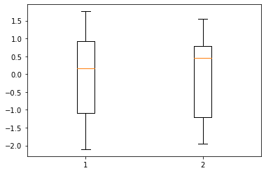

```python
plt.boxplot(X)
```

```python
print('Xmean', np.mean(X))
print('Xvar', np.var(X))
```

```
Xmean 3.8310095836398736e-16
Xvar 1.0000000000000007
```

### Modelado

DBSCAN significa Density-based Spatial Clustering of Applications with Noise (Clustering espacial basado en densidad de aplicaciones con ruido). Esta técnica es una de las más comunes de algoritmos de clustering, que funciona en base a la densidad del objeto. DBSCAN trabaja en la idea de que si un punto en particular pertenece a un cluster, debería estar cerca de un montón de otros puntos en ese cluster.

Funciona en base a 2 parámetros: Radius (Radio) y Puntos Mínimos.  
**Epsilon** determina un radio especificado que, si incluye suficientes puntos dentro de él, lo llamamos de "área densa". **minimumSamples** determina el número mínimo de puntos de datos que queremos en un neighborhood (vecindario) para definir un cluster.

```python
epsilon = 0.3
minimumSamples = 7
db = DBSCAN(eps=epsilon, min_samples=minimumSamples).fit(X)
labels = db.labels_
labels
```

```
array([0, 1, 1, ..., 2, 0, 1], dtype=int64)
```

### Distinguir Valores Atípicos

Reemplacemos todos los elementos con 'True' en core_samples_mask que estan en el cluster, 'False' si los puntos son valores atípicos (outliers).

```python
# Primer, crear un vector de valores booleanos (valores binarios (verdadero/falso)) usando las etiquetas de la variable db.
core_samples_mask = np.zeros_like(db.labels_, dtype=bool)
core_samples_mask[db.core_sample_indices_] = True
core_samples_mask
```

```
array([ True,  True,  True, ...,  True,  True,  True])
```

```python
# Número de clusters en etiquetas, ignorando el ruido en caso de estar presente.
n_clusters_ = len(set(labels)) - (1 if -1 in labels else 0)
n_clusters_
```

```
3
```

```python
# Eliminar la repetición en las etiquetas transformándolas en un conjunto.
unique_labels = set(labels)
unique_labels
```

```
{0, 1, 2}
```

### Visualización de Datos

```python
# Crear colores para los clusters.
colors = plt.cm.Spectral(np.linspace(0, 1, len(unique_labels)))
colors
```

```
array([[0.61960784, 0.00392157, 0.25882353, 1.        ],
       [0.99807766, 0.99923106, 0.74602076, 1.        ],
       [0.36862745, 0.30980392, 0.63529412, 1.        ]])
```

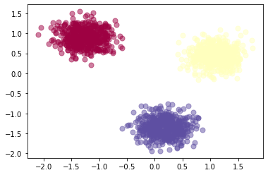

```python
# Dibujar los puntos con colores
for k, col in zip(unique_labels, colors):
    if k == -1:
        # El color negro se utilizará para señalar ruido en los datos.
        col = 'k'

    class_member_mask = (labels == k)

    # Dibujoar los datos que estan agrupados (clusterizados)
    xy = X[class_member_mask & core_samples_mask]
    plt.scatter(xy[:, 0], xy[:, 1],s=50, color=col, marker=u'o', alpha=0.5)

    # Dibujar los valores atípicos
    xy = X[class_member_mask & ~core_samples_mask]
    plt.scatter(xy[:, 0], xy[:, 1],s=50, color=col, marker=u'o', alpha=0.5)
```

## Práctica

Para entender mejor las diferencias entre el clustering basado en densidad y el basado en partición, intentaremos agrupar el conjunto de datos anterior en 3 clusters usando k-Medias. Nota: no generar datos de nuevo, utilizaremos el mismo del punto anterior.

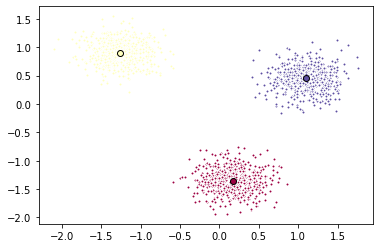

```python
# escribir código aquí
from sklearn.cluster import KMeans
ncluster = 3
#Entrenar el Modelo y Predecir
k_means_n = KMeans(init = "k-means++", n_clusters = ncluster, n_init = 12)
k_means_n.fit(X)
k_means_labels = k_means.labels_
fig = plt.figure(figsize=(6, 4))
ax = fig.add_subplot(1, 1, 1)
for k, col in zip(range(len(k_means_n.cluster_centers_)), colors):
    my_members = (k_means_n.labels_ == k)
    cluster_center = k_means_n.cluster_centers_[k]
    ax.plot(X[my_members, 0], X[my_members, 1], 'w', markerfacecolor=col, marker='.')
    ax.plot(cluster_center[0], cluster_center[1], 'o', markerfacecolor=col,  markeredgecolor='k', markersize=6)
plt.show()
```

# Weather Station Clustering usando DBSCAN & scikit-learn

<Click 1> DBSCAN puede ser usado aquí para encontrar el grupo de estaciones, que muestran las mismas condiciones climáticas. Como puede ver,no sólo encuentra diferentes clusteres en forma arbitraria, sino que puede encontrar la parte más densa de las muestras centradas en datos ignorando áreas menos densas o ruidos.

comencemos jugando con los datos. Estaremos trabajando en función de la siguiente secuencia: </font>

1. Cargar datos
- Revisar datos
- Limpiar datos
- Seleccionar datos
- Clustering

### Acerca del set de datos

#### Environment Canada Monthly Values for July - 2015

| Name in the table | Meaning |
| --- | --- |
| **Stn_Name** | **Station Name** |
| **Lat** | **Latitude (North+, degrees)** |
| **Long** | **Longitude (West - , degrees)** |
| Prov | Province |
| Tm | Mean Temperature (°C) |
| DwTm | Days without Valid Mean Temperature |
| D | Mean Temperature difference from Normal (1981-2010) (°C) |
| Tx | Highest Monthly Maximum Temperature (°C) |
| DwTx | Days without Valid Maximum Temperature |
| Tn | Lowest Monthly Minimum Temperature (°C) |
| DwTn | Days without Valid Minimum Temperature |
| S | Snowfall (cm) |
| DwS | Days without Valid Snowfall |
| S%N | Percent of Normal (1981-2010) Snowfall |
| **P** | **Total Precipitation (mm)** |
| DwP | Days without Valid Precipitation |
| P%N | Percent of Normal (1981-2010) Precipitation |
| S_G | Snow on the ground at the end of the month (cm) |
| Pd | Number of days with Precipitation 1.0 mm or more |
| BS | Bright Sunshine (hours) |
| DwBS | Days without Valid Bright Sunshine |
| BS% | Percent of Normal (1981-2010) Bright Sunshine |
| HDD | Degree Days below 18 °C |
| CDD | Degree Days above 18 °C |
| Stn_No | Climate station identifier (first 3 digits indicate drainage basin, last 4 characters are for sorting alphabetically). |
| NA | Not Available |

### 1-Descargar los datos

Para descargar los datos, utilizaremos **`!wget`** de IBM Object Storage.  
**¿Sabías?** Cuando se trata de Machine Learning, seguro trabajarás con grandes datasets (juego de datos). Entonces, ¿dónde podrás guardar esos datos? IBM ofrece una oportunidad única para las empresas, con 10 Tb de IBM Cloud Object Storage: [Registrate ahora gratuitamente] (http://cocl.us/ML0101EN-IBM-Offer-CC)

```python
!wget -O weather-stations20140101-20141231.csv https://s3-api.us-geo.objectstorage.softlayer.net/cf-courses-data/CognitiveClass/ML0101ENv3/labs/weather-stations20140101-20141231.csv
```

### 2- Cargar el set de datos

```python
import csv
import pandas as pd
import numpy as np

filename=f'..\weather-stations20140101-20141231.csv'

#Read csv
pdf = pd.read_csv(filename)
pdf.head(5)
```

|  | Stn_Name | Lat | Long | Prov | Tm | DwTm | D | Tx | DwTx | Tn | ... | DwP | P%N | S_G | Pd | BS | DwBS | BS% | HDD | CDD | Stn_No |
| --- | --- | --- | --- | --- | --- | --- | --- | --- | --- | --- | --- | --- | --- | --- | --- | --- | --- | --- | --- | --- | --- |
| 0 | CHEMAINUS | 48.935 | -123.742 | BC | 8.2 | 0.0 | NaN | 13.5 | 0.0 | 1.0 | ... | 0.0 | NaN | 0.0 | 12.0 | NaN | NaN | NaN | 273.3 | 0.0 | 1011500 |
| 1 | COWICHAN LAKE FORESTRY | 48.824 | -124.133 | BC | 7.0 | 0.0 | 3.0 | 15.0 | 0.0 | -3.0 | ... | 0.0 | 104.0 | 0.0 | 12.0 | NaN | NaN | NaN | 307.0 | 0.0 | 1012040 |
| 2 | LAKE COWICHAN | 48.829 | -124.052 | BC | 6.8 | 13.0 | 2.8 | 16.0 | 9.0 | -2.5 | ... | 9.0 | NaN | NaN | 11.0 | NaN | NaN | NaN | 168.1 | 0.0 | 1012055 |
| 3 | DISCOVERY ISLAND | 48.425 | -123.226 | BC | NaN | NaN | NaN | 12.5 | 0.0 | NaN | ... | NaN | NaN | NaN | NaN | NaN | NaN | NaN | NaN | NaN | 1012475 |
| 4 | DUNCAN KELVIN CREEK | 48.735 | -123.728 | BC | 7.7 | 2.0 | 3.4 | 14.5 | 2.0 | -1.0 | ... | 2.0 | NaN | NaN | 11.0 | NaN | NaN | NaN | 267.7 | 0.0 | 1012573 |

5 rows × 25 columns

```python
pdf.dtypes
```

```
Stn_Name     object
Lat         float64
Long        float64
Prov         object
Tm          float64
DwTm        float64
D           float64
Tx          float64
DwTx        float64
Tn          float64
DwTn        float64
S           float64
DwS         float64
S%N         float64
P           float64
DwP         float64
P%N         float64
S_G         float64
Pd          float64
BS          float64
DwBS        float64
BS%         float64
HDD         float64
CDD         float64
Stn_No       object
dtype: object
```

### 3-Limpieza

Saquemos las filas que no tienen valor en el campo **Tm**.

```python
pdf = pdf[pd.notnull(pdf["Tm"])]
pdf = pdf.reset_index(drop=True)
pdf.head(5)
```

|  | Stn_Name | Lat | Long | Prov | Tm | DwTm | D | Tx | DwTx | Tn | ... | DwP | P%N | S_G | Pd | BS | DwBS | BS% | HDD | CDD | Stn_No |
| --- | --- | --- | --- | --- | --- | --- | --- | --- | --- | --- | --- | --- | --- | --- | --- | --- | --- | --- | --- | --- | --- |
| 0 | CHEMAINUS | 48.935 | -123.742 | BC | 8.2 | 0.0 | NaN | 13.5 | 0.0 | 1.0 | ... | 0.0 | NaN | 0.0 | 12.0 | NaN | NaN | NaN | 273.3 | 0.0 | 1011500 |
| 1 | COWICHAN LAKE FORESTRY | 48.824 | -124.133 | BC | 7.0 | 0.0 | 3.0 | 15.0 | 0.0 | -3.0 | ... | 0.0 | 104.0 | 0.0 | 12.0 | NaN | NaN | NaN | 307.0 | 0.0 | 1012040 |
| 2 | LAKE COWICHAN | 48.829 | -124.052 | BC | 6.8 | 13.0 | 2.8 | 16.0 | 9.0 | -2.5 | ... | 9.0 | NaN | NaN | 11.0 | NaN | NaN | NaN | 168.1 | 0.0 | 1012055 |
| 3 | DUNCAN KELVIN CREEK | 48.735 | -123.728 | BC | 7.7 | 2.0 | 3.4 | 14.5 | 2.0 | -1.0 | ... | 2.0 | NaN | NaN | 11.0 | NaN | NaN | NaN | 267.7 | 0.0 | 1012573 |
| 4 | ESQUIMALT HARBOUR | 48.432 | -123.439 | BC | 8.8 | 0.0 | NaN | 13.1 | 0.0 | 1.9 | ... | 8.0 | NaN | NaN | 12.0 | NaN | NaN | NaN | 258.6 | 0.0 | 1012710 |

5 rows × 25 columns

### 4-Visualización

Visualización de estaciones usando el package basemap. El toolkit basemap matplotlib es una librería para dibujo de mapas en 2D en Python. Basemap no dibuja por sí mismo, sino que facilita la transformación de las coordenadas a proyecciones de mapas.

```python
from mpl_toolkits.basemap import Basemap #you must use Cartopy instead
import matplotlib.pyplot as plt
from pylab import rcParams
%matplotlib inline
rcParams['figure.figsize'] = (14,10)

llon=-140
ulon=-50
llat=40
ulat=65

pdf = pdf[(pdf['Long'] > llon) & (pdf['Long'] < ulon) & (pdf['Lat'] > llat) &(pdf['Lat'] < ulat)]

my_map = Basemap(projection='merc',
            resolution = 'l', area_thresh = 1000.0,
            llcrnrlon=llon, llcrnrlat=llat, #min longitude (llcrnrlon) and latitude (llcrnrlat)
            urcrnrlon=ulon, urcrnrlat=ulat) #max longitude (urcrnrlon) and latitude (urcrnrlat)

my_map.drawcoastlines()
my_map.drawcountries()
# my_map.drawmapboundary()
my_map.fillcontinents(color = 'white', alpha = 0.3)
my_map.shadedrelief()

# To collect data based on stations

xs,ys = my_map(np.asarray(pdf.Long), np.asarray(pdf.Lat))
pdf['xm']= xs.tolist()
pdf['ym'] =ys.tolist()

#Visualization1
for index,row in pdf.iterrows():
#   x,y = my_map(row.Long, row.Lat)
   my_map.plot(row.xm, row.ym,markerfacecolor =([1,0,0]),  marker='o', markersize= 5, alpha = 0.75)
#plt.text(x,y,stn)
plt.show()
```

[output not shown]

### 5- Clustering de las estaciones basado en su ubicación i.e. Lat & Lon

**DBSCAN** (parte de la librería sklearn) ejecuta el clustering desde un vector o una matriz de distancia. En nuestro caso, pasamos el arregloNumpy array Clus_dataSet para encontrar ejemplos de alta densidad y expandir clusters a partir de ellos.

```python
from sklearn.cluster import DBSCAN
import sklearn.utils
from sklearn.preprocessing import StandardScaler
sklearn.utils.check_random_state(1000)
Clus_dataSet = pdf[['xm','ym']]
Clus_dataSet = np.nan_to_num(Clus_dataSet)
Clus_dataSet = StandardScaler().fit_transform(Clus_dataSet)

# Calcular con DBSCAN
db = DBSCAN(eps=0.15, min_samples=10).fit(Clus_dataSet)
core_samples_mask = np.zeros_like(db.labels_, dtype=bool)
core_samples_mask[db.core_sample_indices_] = True
labels = db.labels_
pdf["Clus_Db"]=labels

realClusterNum=len(set(labels)) - (1 if -1 in labels else 0)
clusterNum = len(set(labels))


# Muestra de clusters
pdf[["Stn_Name","Tx","Tm","Clus_Db"]].head(5)
```

[output not shown]

```python
set(labels)
```

### 6- Visualización de clusters basados en ubicación

Ahora, podemos visualizar los clusters usando basemap:

```python
from mpl_toolkits.basemap import Basemap
import matplotlib.pyplot as plt
from pylab import rcParams
%matplotlib inline
rcParams['figure.figsize'] = (14,10)

my_map = Basemap(projection='merc',
            resolution = 'l', area_thresh = 1000.0,
            llcrnrlon=llon, llcrnrlat=llat, #min longitude (llcrnrlon) and latitude (llcrnrlat)
            urcrnrlon=ulon, urcrnrlat=ulat) #max longitude (urcrnrlon) and latitude (urcrnrlat)

my_map.drawcoastlines()
my_map.drawcountries()
#my_map.drawmapboundary()
my_map.fillcontinents(color = 'white', alpha = 0.3)
my_map.shadedrelief()

# Para crear un mapa de colores
colors = plt.get_cmap('jet')(np.linspace(0.0, 1.0, clusterNum))



#Visualización
for clust_number in set(labels):
    c=(([0.4,0.4,0.4]) if clust_number == -1 else colors[np.int(clust_number)])
    clust_set = pdf[pdf.Clus_Db == clust_number]
    my_map.scatter(clust_set.xm, clust_set.ym, color =c,  marker='o', s= 20, alpha = 0.85)
    if clust_number != -1:
        cenx=np.mean(clust_set.xm)
        ceny=np.mean(clust_set.ym)
        plt.text(cenx,ceny,str(clust_number), fontsize=25, color='red',)
        print ("Cluster "+str(clust_number)+', Avg Temp: '+ str(np.mean(clust_set.Tm)))
```

[output not shown]

### 7- Clustering de estaciones basado en su ubicacion, temperatura promedio, máxima y mínima

En esta sección, volvemos a ejecutar DBSCAN, pero esta vez, en un dataset de 5-dimensiones:

```python
from sklearn.cluster import DBSCAN
import sklearn.utils
from sklearn.preprocessing import StandardScaler
sklearn.utils.check_random_state(1000)
Clus_dataSet = pdf[['xm','ym','Tx','Tm','Tn']]
Clus_dataSet = np.nan_to_num(Clus_dataSet)
Clus_dataSet = StandardScaler().fit_transform(Clus_dataSet)

# Computar DBSCAN
db = DBSCAN(eps=0.3, min_samples=10).fit(Clus_dataSet)
core_samples_mask = np.zeros_like(db.labels_, dtype=bool)
core_samples_mask[db.core_sample_indices_] = True
labels = db.labels_
pdf["Clus_Db"]=labels

realClusterNum=len(set(labels)) - (1 if -1 in labels else 0)
clusterNum = len(set(labels))


# Una muestra de clusters
pdf[["Stn_Name","Tx","Tm","Clus_Db"]].head(5)
```

[output not shown]

### 8- Visualización de clusters basados en ubicación y temperatura

```python
from mpl_toolkits.basemap import Basemap
import matplotlib.pyplot as plt
from pylab import rcParams
%matplotlib inline
rcParams['figure.figsize'] = (14,10)

my_map = Basemap(projection='merc',
            resolution = 'l', area_thresh = 1000.0,
            llcrnrlon=llon, llcrnrlat=llat, #min longitude (llcrnrlon) and latitude (llcrnrlat)
            urcrnrlon=ulon, urcrnrlat=ulat) #max longitude (urcrnrlon) and latitude (urcrnrlat)

my_map.drawcoastlines()
my_map.drawcountries()
#my_map.drawmapboundary()
my_map.fillcontinents(color = 'white', alpha = 0.3)
my_map.shadedrelief()

# Para crear un mapa de color
colors = plt.get_cmap('jet')(np.linspace(0.0, 1.0, clusterNum))



#Visualización1
for clust_number in set(labels):
    c=(([0.4,0.4,0.4]) if clust_number == -1 else colors[np.int(clust_number)])
    clust_set = pdf[pdf.Clus_Db == clust_number]
    my_map.scatter(clust_set.xm, clust_set.ym, color =c,  marker='o', s= 20, alpha = 0.85)
    if clust_number != -1:
        cenx=np.mean(clust_set.xm)
        ceny=np.mean(clust_set.ym)
        plt.text(cenx,ceny,str(clust_number), fontsize=25, color='red',)
        print ("Cluster "+str(clust_number)+', Avg Temp: '+ str(np.mean(clust_set.Tm)))
```

[output not shown]

## Want to learn more?

IBM SPSS Modeler es una plataforma para analytics que contiene varios algoritmos de machine learning. Fue diseñada para acercar inteligencia predictiva a las decisiones hechas por individuos, grupos, sistemas, toda la empresa. Un free trial está disponible a través de este curso en: [SPSS Modeler](http://cocl.us/ML0101EN-SPSSModeler).

Asi mismo, puedes utilizar Watson Studio para ejecutar estos notebooks más rápido y con datasets más grandes. Watson Studio es una solución en la nube lider de IBM's para científicos de datos, construída por científicos de datos. Con Jupyter notebooks, RStudio, Apache Spark y librerías conocidas pre instaladas en la nube, Watson Studio posibilita a los científicos de datos colaborar en sus proyectos sin tener que instalar nada. Sumate a la comunidad de usuarios Watson Studio hoy mismo por medio de una cuenta gratuita en [Watson Studio](https://cocl.us/ML0101EN_DSX)

### ¡Gracias por completar esta lección!

Notebook creado por: [Saeed Aghabozorgi](https://ca.linkedin.com/in/saeedaghabozorgi)

Copyright © 2018 [Cognitive Class](https://cocl.us/DX0108EN_CC). Este lab y su código fuente fueron registrados bajo los términos de [MIT License](https://bigdatauniversity.com/mit-license/).